# IODS course project

# Chapter 6 Analysis of longitudinal data

Implementing the analyses of Chapter 8 using the RATS data, and the analyses of Chapter 9 using the BPRS data. Let’s see how this goes!

First some prepping of the data:

```r
# Last analysis exercise ahead, let's go!
# Read the data
# First the longitudial
bprsl <- read.csv("~/IODS-project/data/bprs_long.csv")
ratsl <- read.csv("~/IODS-project/data/rats_long.csv")
# Then the old data
BPRS <- read.csv("~/IODS-project/data/BPRS.csv")
RATS <- read.csv("~/IODS-project/data/RATS.csv")

# Removing the first columns that R added automatically
bprsl <- bprsl[, -1]
ratsl <- ratsl[, -1]
# Make categorical variables to factors
bprsl$treatment <- factor(bprsl$treatment)
bprsl$subject <- factor(bprsl$subject)
ratsl$Group <- factor(ratsl$Group)
ratsl$ID <- factor(ratsl$ID)
BPRS$treatment <- factor(BPRS$treatment)
BPRS$subject <- factor(BPRS$subject)
RATS$Group <- factor(RATS$Group)
RATS$ID <- factor(RATS$ID)

# Let's summarise the data
glimpse(bprsl)
```

```
## Rows: 360
## Columns: 5
## $ treatment <fct> 1, 1, 1, 1, 1, 1, 1, 1, 1, 1, 1, 1, 1, 1, 1, 1, 1, 1, 1, 1, …
## $ subject   <fct> 1, 2, 3, 4, 5, 6, 7, 8, 9, 10, 11, 12, 13, 14, 15, 16, 17, 1…
## $ weeks     <chr> "week0", "week0", "week0", "week0", "week0", "week0", "week0…
## $ bprs      <int> 42, 58, 54, 55, 72, 48, 71, 30, 41, 57, 30, 55, 36, 38, 66, …
## $ week      <int> 0, 0, 0, 0, 0, 0, 0, 0, 0, 0, 0, 0, 0, 0, 0, 0, 0, 0, 0, 0, …
```

```r
glimpse(ratsl)
```

```
## Rows: 176
## Columns: 5
## $ ID    <fct> 1, 2, 3, 4, 5, 6, 7, 8, 9, 10, 11, 12, 13, 14, 15, 16, 1, 2, 3, …
## $ Group <fct> 1, 1, 1, 1, 1, 1, 1, 1, 2, 2, 2, 2, 3, 3, 3, 3, 1, 1, 1, 1, 1, 1…
## $ WD    <chr> "WD1", "WD1", "WD1", "WD1", "WD1", "WD1", "WD1", "WD1", "WD1", "…
## $ rats  <int> 240, 225, 245, 260, 255, 260, 275, 245, 410, 405, 445, 555, 470,…
## $ Time  <int> 1, 1, 1, 1, 1, 1, 1, 1, 1, 1, 1, 1, 1, 1, 1, 1, 15, 15, 15, 15, …
```

```r
summary(bprsl)
```

```
##  treatment    subject       weeks                bprs            week
##  1:180     1      : 18   Length:360         Min.   :18.00   Min.   :0
##  2:180     2      : 18   Class :character   1st Qu.:27.00   1st Qu.:2
##            3      : 18   Mode  :character   Median :35.00   Median :4
##            4      : 18                      Mean   :37.66   Mean   :4
##            5      : 18                      3rd Qu.:43.00   3rd Qu.:6
##            6      : 18                      Max.   :95.00   Max.   :8
##            (Other):252
```

```r
summary(ratsl)
```

```
##        ID      Group       WD                 rats            Time
##  1      : 11   1:88   Length:176         Min.   :225.0   Min.   : 1.00
##  2      : 11   2:44   Class :character   1st Qu.:267.0   1st Qu.:15.00
##  3      : 11   3:44   Mode  :character   Median :344.5   Median :36.00
##  4      : 11                             Mean   :384.5   Mean   :33.55
##  5      : 11                             3rd Qu.:511.2   3rd Qu.:50.00
##  6      : 11                             Max.   :628.0   Max.   :64.00
##  (Other):110
```

In the Part one, we work with the ratsl (and RATS) data. The data is from a nutrition study conducted in three groups of rats. The groups were put on different diets, and each animal’s body weight (grams) was recorded repeatedly (approximately) weekly, except in week seven when two recordings were taken) over a 9-week period. The question of most interest is whether the growth profiles of the three groups differ.

This far all good… Then the actual analyses exercises. First, Chapter 8 exercises:

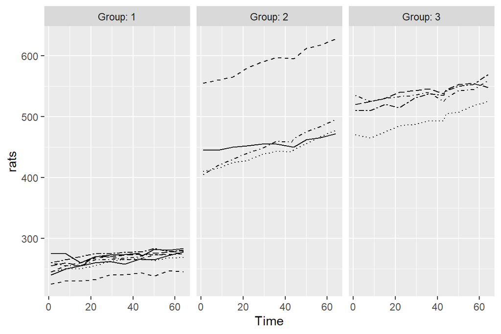

```r
# Drawing a plot with Time on x-axis and rats on the y-axis
# Access the package ggplot2
library(ggplot2)

# Draw the plot
ggplot(ratsl, aes(x = Time, y = rats, linetype = ID)) +
  geom_line() +
  scale_linetype_manual(values = rep(1:10, times=4)) +
  facet_grid(. ~ Group, labeller = label_both) +
  theme(legend.position = "none") +
  scale_y_continuous(limits = c(min(ratsl$rats), max(ratsl$rats)))
```

In the plot it can be seen that the three groups of rats differ quite significantly in their weight. Rats in the group 1 weight absolutely least, whereas the difference is not as big between groups 2 and 3. Group 2 has a significant outlier; in group 3 there is also one observation that can be distinguished from the rest but not as notable.

Let’s then standardise the weight of the rats, `rats` variable by grouping variable `Time`

```r
library(dplyr)
library(tidyr)
```

```r
# Standardise the variable rats
ratsl <- ratsl %>%
  group_by(Time) %>%
  mutate(stdrats = (rats - mean(rats))/sd(rats) ) %>%
  ungroup()

# Glimpse the data
glimpse(ratsl)
```

```
## Rows: 176
## Columns: 6
## $ ID      <fct> 1, 2, 3, 4, 5, 6, 7, 8, 9, 10, 11, 12, 13, 14, 15, 16, 1, 2, 3…
## $ Group   <fct> 1, 1, 1, 1, 1, 1, 1, 1, 2, 2, 2, 2, 3, 3, 3, 3, 1, 1, 1, 1, 1,…
## $ WD      <chr> "WD1", "WD1", "WD1", "WD1", "WD1", "WD1", "WD1", "WD1", "WD1",…
## $ rats    <int> 240, 225, 245, 260, 255, 260, 275, 245, 410, 405, 445, 555, 47…
## $ Time    <int> 1, 1, 1, 1, 1, 1, 1, 1, 1, 1, 1, 1, 1, 1, 1, 1, 15, 15, 15, 15…
## $ stdrats <dbl> -1.0011429, -1.1203857, -0.9613953, -0.8421525, -0.8819001, -0…
```

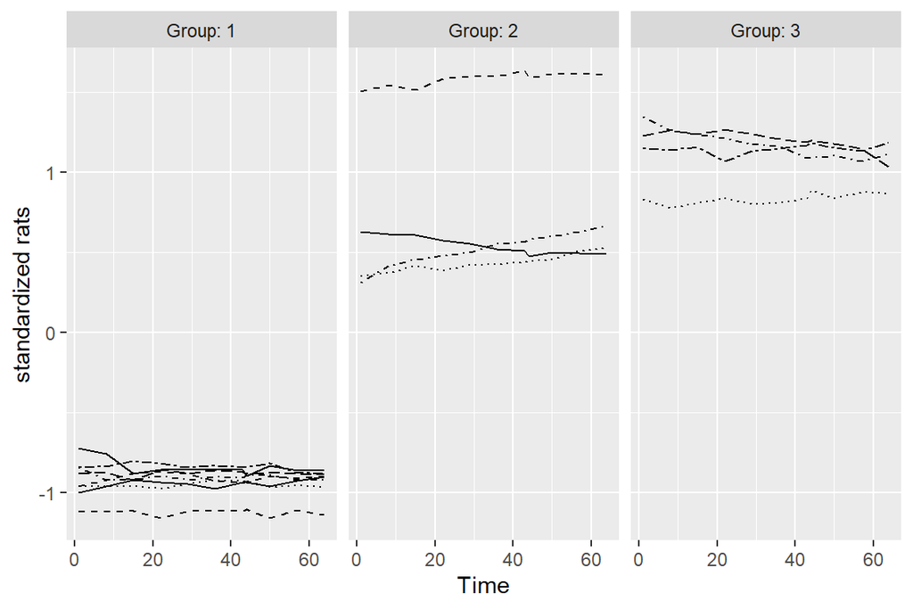

```r
# Plotting again with the standardized rats
library(ggplot2)
ggplot(ratsl, aes(x = Time, y = stdrats, linetype = ID)) +
  geom_line() +
  scale_linetype_manual(values = rep(1:10, times=4)) +
  facet_grid(. ~ Group, labeller = label_both) +
  theme(legend.position = "none") +
  scale_y_continuous(name = "standardized rats")
```

The weights do not increase with time now; this is good news for the accuracy of the analysis.

Hint: - Calculate the summary variables `mean` and `se` inside the `summarise()` function

```r
# Create summary data
n <- ratsl$Time %>% unique() %>% length()
ratss <- ratsl %>%
  group_by(Time, Group) %>%
  summarise( mean = mean(rats), se = sd(rats)/sqrt(n) ) %>%
  ungroup()
# Let's see
glimpse(ratss)
```

```
## Rows: 33
## Columns: 4
## $ Time  <int> 1, 1, 1, 8, 8, 8, 15, 15, 15, 22, 22, 22, 29, 29, 29, 36, 36, 36…
## $ Group <fct> 1, 2, 3, 1, 2, 3, 1, 2, 3, 1, 2, 3, 1, 2, 3, 1, 2, 3, 1, 2, 3, 1…
## $ mean  <dbl> 250.625, 453.750, 508.750, 255.000, 460.000, 506.250, 254.375, 4…
## $ se    <dbl> 4.589478, 21.047385, 8.382431, 3.947710, 20.486507, 8.561276, 3.…
```

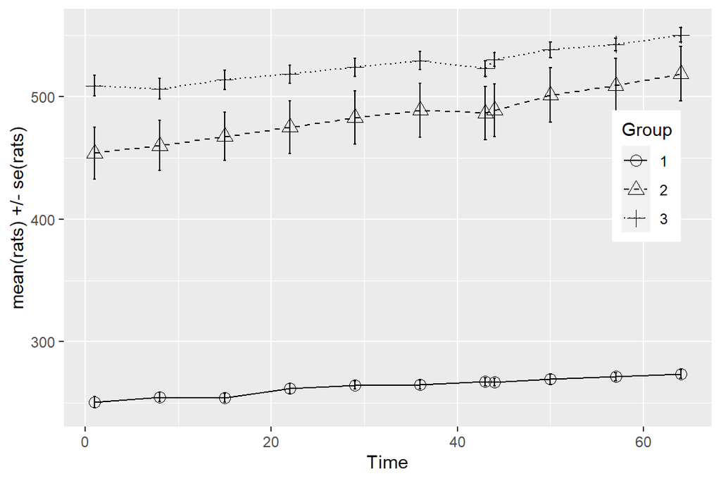

```r
# Plot the mean profiles
library(ggplot2)
ggplot(ratss, aes(x = Time, y = mean, linetype = Group, shape = Group)) +
  geom_line() +
  scale_linetype_manual(values = c(1,2,3)) +
  geom_point(size=3) +
  scale_shape_manual(values = c(1,2,3)) +
 geom_errorbar(aes(ymin=mean-se, ymax=mean+se, linetype="1"), width=0.3) +
  theme(legend.position = c(0.9,0.6)) +
  scale_y_continuous(name = "mean(rats) +/- se(rats)")
```

Now this plot represents the data more in the way of the original dataset, plotting the values by week. Here we can still see that the Group 1 is the lightest by marginal, while Group 2 is just a little lighter than Group 3. It can also be seen that Group 1 has rather little variation in comparison with the two other groups.

In Groups 2 and 3 we had the significant outliers, let’s take a look at them. This is a job for boxplots!

*Instructions* - Create the summary data BPRSL8S - Glimpse the data - Draw the boxplot and observe the outlier - Find a suitable threshold value and use `filter()` to exclude the outlier to form a new data BPRSL8S1 - Glimpse and draw a boxplot of the new data to check the outlier has been dealt with

```r
library(dplyr)
library(tidyr)
# Create a summary data by treatment and subject with mean as the summary variable (ignoring baseline Time 0)
rats_sum <- ratsl %>%
  filter(Time > 0) %>%
  group_by(Group, ID) %>%
  summarise( mean=mean(rats) ) %>%
  ungroup()
# Glimpse the data
glimpse(rats_sum)
```

```
## Rows: 16
## Columns: 3
## $ Group <fct> 1, 1, 1, 1, 1, 1, 1, 1, 2, 2, 2, 2, 3, 3, 3, 3
## $ ID    <fct> 1, 2, 3, 4, 5, 6, 7, 8, 9, 10, 11, 12, 13, 14, 15, 16
## $ mean  <dbl> 261.0909, 237.6364, 260.1818, 266.5455, 269.4545, 274.7273, 274.…
```

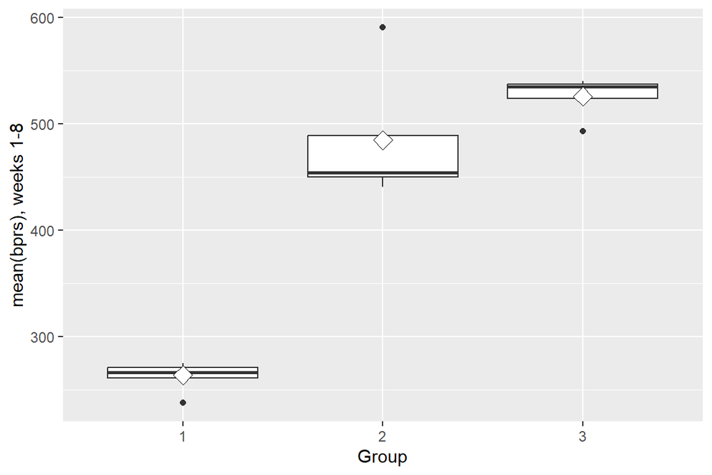

```r
# Draw a boxplot of the mean versus treatment
library(ggplot2)
ggplot(rats_sum, aes(x = Group, y = mean)) +
  geom_boxplot() +
  stat_summary(fun = "mean", geom = "point", shape=23, size=4, fill = "white") +
  scale_y_continuous(name = "mean(bprs), weeks 1-8")
```

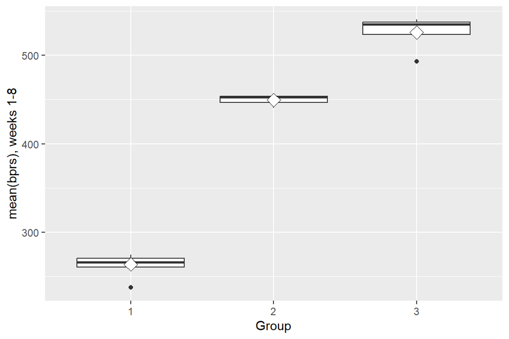

```r
# Create a new data by filtering the outlier and adjust the ggplot code the draw the plot again with the new data
rats_sum_new <- rats_sum %>% filter(mean < 550)

ggplot(rats_sum_new, aes(x = Group, y = mean)) +
  geom_boxplot() +
  stat_summary(fun = "mean", geom = "point", shape=23, size=4, fill = "white") +
  scale_y_continuous(name = "mean(bprs), weeks 1-8")
```

Nice, we got rid of the outlier in Group 2. Groups 1 and 3 seem to also have a slight outlier each, but as they are not as extreme, we’ll let them be. The boxplots show also that there is rather little variance within each group.

Almost done with the first part!

Next, part two with the BPRS data!

The data contains 40 data subjects that received different treatment during eight weeks time. The respondents were rated on the Brief Psychiatric Rating Scale (BPRS) used to evaluate schizophrenia.

```r
# Let's remind ourselves on how the data looks like
colnames(bprsl)
```

```
## [1] "treatment" "subject"   "weeks"     "bprs"      "week"
```

```r
str(bprsl)
```

```
## 'data.frame':    360 obs. of  5 variables:
##  $ treatment: Factor w/ 2 levels "1","2": 1 1 1 1 1 1 1 1 1 1 ...
##  $ subject  : Factor w/ 20 levels "1","2","3","4",..: 1 2 3 4 5 6 7 8 9 10 ...
##  $ weeks    : chr  "week0" "week0" "week0" "week0" ...
##  $ bprs     : int  42 58 54 55 72 48 71 30 41 57 ...
##  $ week     : int  0 0 0 0 0 0 0 0 0 0 ...
```

```r
dim(bprsl)
```

```
## [1] 360   5
```

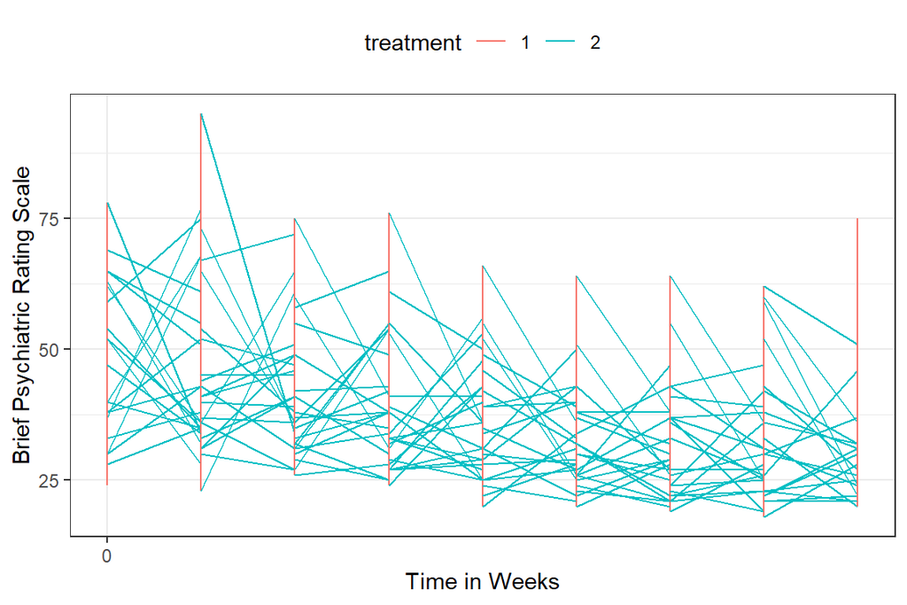

```r
# Moving on to plotting the data
library(dplyr)
library(tidyr)
library(ggplot2)
ggplot(bprsl, aes(x = week, y = bprs, group = subject, color = treatment)) +
  geom_line() +
  scale_x_continuous(name = "Time in Weeks", breaks = seq(0, 60, 10))+
  scale_y_continuous(name = "Brief Psychiatric Rating Scale") +
  theme_bw() +
  theme(legend.position = "top")
```

```r
# Fitting the model
m1 <- lm(bprs ~ week + treatment, data = bprsl)
summary(m1)
```

```
##
## Call:
## lm(formula = bprs ~ week + treatment, data = bprsl)
##
## Residuals:
##     Min      1Q  Median      3Q     Max
## -22.454  -8.965  -3.196   7.002  50.244
##
## Coefficients:
##             Estimate Std. Error t value Pr(>|t|)
## (Intercept)  46.4539     1.3670  33.982   <2e-16 ***
## week         -2.2704     0.2524  -8.995   <2e-16 ***
## treatment2    0.5722     1.3034   0.439    0.661
## ---
## Signif. codes:  0 '***' 0.001 '**' 0.01 '*' 0.05 '.' 0.1 ' ' 1
##
## Residual standard error: 12.37 on 357 degrees of freedom
## Multiple R-squared:  0.1851, Adjusted R-squared:  0.1806
## F-statistic: 40.55 on 2 and 357 DF,  p-value: < 2.2e-16
```

```r
# access library lme4
library(lme4)
# Create a random intercept model
m2 <- lmer(bprs ~ week + treatment + (1 | subject), data = bprsl, REML = FALSE)
summary(m2)
```

```
## Linear mixed model fit by maximum likelihood  ['lmerMod']
## Formula: bprs ~ week + treatment + (1 | subject)
##    Data: bprsl
##
##      AIC      BIC   logLik deviance df.resid
##   2748.7   2768.1  -1369.4   2738.7      355
##
## Scaled residuals:
##     Min      1Q  Median      3Q     Max
## -3.0481 -0.6749 -0.1361  0.4813  3.4855
##
## Random effects:
##  Groups   Name        Variance Std.Dev.
##  subject  (Intercept)  47.41    6.885
##  Residual             104.21   10.208
## Number of obs: 360, groups:  subject, 20
##
## Fixed effects:
##             Estimate Std. Error t value
## (Intercept)  46.4539     1.9090  24.334
## week         -2.2704     0.2084 -10.896
## treatment2    0.5722     1.0761   0.532
##
## Correlation of Fixed Effects:
##            (Intr) week
## week       -0.437
## treatment2 -0.282  0.000
```

```r
# Create a random intercept and slope model
m3 <- lmer(bprs ~ week + treatment + (week | subject), data = bprsl, REML = FALSE)
summary(m3)
```

```
## Linear mixed model fit by maximum likelihood  ['lmerMod']
## Formula: bprs ~ week + treatment + (week | subject)
##    Data: bprsl
##
##      AIC      BIC   logLik deviance df.resid
##   2745.4   2772.6  -1365.7   2731.4      353
##
## Scaled residuals:
##     Min      1Q  Median      3Q     Max
## -2.8919 -0.6194 -0.0691  0.5531  3.7976
##
## Random effects:
##  Groups   Name        Variance Std.Dev. Corr
##  subject  (Intercept) 64.8222  8.0512
##           week         0.9609  0.9802   -0.51
##  Residual             97.4305  9.8707
## Number of obs: 360, groups:  subject, 20
##
## Fixed effects:
##             Estimate Std. Error t value
## (Intercept)  46.4539     2.1052  22.066
## week         -2.2704     0.2977  -7.626
## treatment2    0.5722     1.0405   0.550
##
## Correlation of Fixed Effects:
##            (Intr) week
## week       -0.582
## treatment2 -0.247  0.000
```

Lastly, I fit a random intercept and slope model that allows for a treatment × time interaction.

```r
# A random intercept and slope model with treatment x time interaction
m4 <- lmer(bprs ~ week + treatment + (week | subject) + (treatment * week), data = bprsl, REML = FALSE)
summary(m4)
```

```
## Linear mixed model fit by maximum likelihood  ['lmerMod']
## Formula: bprs ~ week + treatment + (week | subject) + (treatment * week)
##    Data: bprsl
##
##      AIC      BIC   logLik deviance df.resid
##   2744.3   2775.4  -1364.1   2728.3      352
##
## Scaled residuals:
##     Min      1Q  Median      3Q     Max
## -3.0512 -0.6271 -0.0768  0.5288  3.9260
##
## Random effects:
##  Groups   Name        Variance Std.Dev. Corr
##  subject  (Intercept) 64.9964  8.0620
##           week         0.9687  0.9842   -0.51
##  Residual             96.4707  9.8220
## Number of obs: 360, groups:  subject, 20
##
## Fixed effects:
##                 Estimate Std. Error t value
## (Intercept)      47.8856     2.2521  21.262
## week             -2.6283     0.3589  -7.323
## treatment2       -2.2911     1.9090  -1.200
## week:treatment2   0.7158     0.4010   1.785
##
## Correlation of Fixed Effects:
##             (Intr) week   trtmn2
## week        -0.650
## treatment2  -0.424  0.469
## wek:trtmnt2  0.356 -0.559 -0.840
```

```r
# Testing whether the model performs better than the model without the interaction term
# perform an ANOVA test on the two models
anova(m3, m4)
```

```
## Data: bprsl
## Models:
## m3: bprs ~ week + treatment + (week | subject)
## m4: bprs ~ week + treatment + (week | subject) + (treatment * week)
##    npar    AIC    BIC  logLik deviance  Chisq Df Pr(>Chisq)
## m3    7 2745.4 2772.6 -1365.7   2731.4
## m4    8 2744.3 2775.4 -1364.1   2728.3 3.1712  1    0.07495 .
## ---
## Signif. codes:  0 '***' 0.001 '**' 0.01 '*' 0.05 '.' 0.1 ' ' 1
```

That’s it folks, let’s wrap this course up! :)